# Estadística_esperanza_de_vida

**Perspectivas Globales de Salud: Analizando la Esperanza de Vida y su Relación con Indicadores Socioeconómicos**

**Proyecto final de propbabilidad y estadística**

[figure not shown]

**Maestría en Ciencias de Datos**

**Universidad de Sonora**

**Propedeutico: Probabilidad y Estadística**

**Profesora: Dra. Gudelia Figueroa Preciado**

**Alumnas:**

**Estephania Pivac Alcaraz**

**Vesna Camile Pivac Alcaraz**

## 1. Selección del problema

El análisis de regresión lineal es una herramienta estadística fundamental para explorar la relación entre variables predictoras y una variable objetivo. En el contexto de la esperanza de vida al nacer y el nivel de desarrollo de un país, el análisis de regresión lineal nos permite investigar cómo los factores socioeconómicos influyen en la esperanza de vida de una población. La esperanza de vida al nacer es un indicador crítico de la calidad de vida y el bienestar de una sociedad, mientras que los factores socioeconómicos reflejan el nivel de desarrollo económico y social de un país.

Para abordar este problema, se utilizarán métodos estadísticos, como el análisis de correlación y regresión, para analizar la relación entre las variables y evaluar su fuerza y dirección en el contexto global. Se recopilarán datos de la esperanza de vida al nacer y los indicadores de desarrollo de cada país durante el periodo de 2000 a 2014 para realizar el análisis comparativo.

El objetivo de este trabajo es examinar la relación entre los factores socioeconómicos y la esperanza de vida al nacer a escala global. Se recopilarán datos de diferentes países durante un periodo de tiempo determinado para identificar los factores que tienen un impacto significativo en la esperanza de vida y evaluar la fuerza y dirección de esta relación.

Este análisis de regresión lineal entre factores socioeconómicos y la esperanza de vida a nivel global tiene implicaciones importantes para la salud pública y el desarrollo socioeconómico. Proporcionará información valiosa sobre los determinantes clave de la esperanza de vida y ayudará a identificar qué factores socioeconómicos tienen un impacto significativo en la calidad de vida de las poblaciones. Se espera que este estudio proporcione información clave para la formulación de políticas y estrategias de desarrollo socioeconómico y de salud, así como para la implementación de intervenciones efectivas. Al comprender cómo los factores socioeconómicos afectan la esperanza de vida, se podrán diseñar medidas dirigidas a mejorar la calidad de vida y el bienestar de las poblaciones en todo el mundo.

En la literatura científica, se han llevado a cabo numerosos estudios que exploran la relación entre el nivel de desarrollo de un país y la esperanza de vida al nacer a nivel nacional y regional. Estos estudios han encontrado consistentemente una asociación positiva. En general, los países con un mayor nivel de desarrollo económico y social tienen una esperanza de vida más alta en comparación con los países menos desarrollados.

Sin embargo, existen variaciones significativas en los patrones de esperanza de vida y desarrollo entre diferentes países y regiones. Algunos países en desarrollo han logrado mejorar significativamente su esperanza de vida a través de mejoras en el acceso a la atención médica, la nutrición y las condiciones sanitarias, mientras que en otros países se han observado desafíos persistentes en términos de esperanza de vida debido a la pobreza, las desigualdades sociales y los sistemas de salud inadecuados.

La disponibilidad de datos a nivel mundial, que abarcan un amplio espectro de países y un periodo de tiempo prolongado, brinda una oportunidad única para analizar y comprender mejor la relación entre el nivel de desarrollo y la esperanza de vida al nacer en el contexto global. Al utilizar técnicas estadísticas avanzadas y análisis de datos, es posible identificar patrones, tendencias y factores clave que influyen en esta relación, lo que puede contribuir a la formulación de políticas y estrategias de desarrollo efectivas en el ámbito de la salud global.

Por lo tanto, el estudio de la relación entre los factores socioeconómicos y la esperanza de vida al nacer a nivel mundial se sitúa en un contexto amplio de salud pública y desarrollo socioeconómico. Los antecedentes existentes sugieren una asociación positiva entre estas variables, pero es necesario llevar a cabo investigaciones más exhaustivas a nivel global para comprender mejor los factores y las disparidades que influyen en esta relación y promover intervenciones efectivas para mejorar la salud y el bienestar de las poblaciones a nivel mundial.

## 2. Descripción del problema: " Análisis de regresión lineal entre factores socioeconómicos y la esperanza de vida al nacer a escala global"

El problema a investigar tiene como objetivo analizar la relación entre los indicadores socioeconómicos y de salud, y la esperanza de vida al nacer a nivel mundial, utilizando datos recopilados durante el periodo de 2000 a 2014.

Se utilizarán diversas variables para evaluar el nivel de desarrollo de un país y su impacto en la esperanza de vida al nacer. En este estudio incluimos:

| No. | Variable | Descripción |
| --- | --- | --- |
| 1 | Country | País |
| 2 | Year | Año |
| 3 | Status | Clasificación de los países como 'desarrollados' o 'en desarrollo' basada en su PIB |
| 4 | Life expectancy | Esperanza de vida al nacer (años) |
| 5 | Adult Mortality | Tasas de mortalidad en adultos de ambos sexos (probabilidad de morir entre los 15 y 60 años) |
| 6 | Infant deaths | Número de muertes de lactantes (0-1 año) por cada 1000 habitantes |
| 7 | Alcohol | Consumo per cápita de alcohol registrado para mayores de 15 años (en litros de alcohol puro) |
| 8 | Percentage expenditure | Gasto en salud como porcentaje del PIB per cápita (%) |
| 9 | Hepatitis B | Cobertura de inmunización contra la hepatitis B entre los niños de 1 año (%) |
| 10 | Measles | Número de casos reportados de sarampión por cada 1000 habitantes |
| 11 | BMI | Índice de masa corporal promedio de la población |
| 12 | Under-five deaths | Número de muertes en menores de cinco años por cada 1000 habitantes |
| 13 | Polio | Cobertura de inmunización contra la polio entre los niños de 1 año (%) |
| 14 | Total expenditure | Gasto general del gobierno en salud como porcentaje del gasto total del gobierno (%) |
| 15 | Diphtheria | Cobertura de inmunización contra la difteria, el tétanos y la tos ferina (DTP3) entre los niños de 1 año (%) |
| 16 | HIV/AIDS | Muertes por VIH/SIDA por cada 1000 nacidos vivos en edades de 0 a 4 años |
| 17 | GDP | Producto Interno Bruto per cápita (en USD) |
| 18 | Population | Población del país |
| 19 | Thinness 1-19 years | Prevalencia de delgadez entre niños y adolescentes de 10 a 19 años (%) |
| 20 | Thinness 5-9 years | Prevalencia de delgadez entre niños de 5 a 9 años (%) |
| 21 | Income composition of resources | Índice de Desarrollo Humano en términos de composición de recursos (índice que varía de 0 a 1) |
| 22 | Schooling | Número de años de escolaridad (años) |

El contexto de este estudio se enmarca a nivel mundial, considerando todos los países del mundo. Se busca comprender cómo el nivel de desarrollo, medido a través de diferentes indicadores, se relaciona con la esperanza de vida al nacer a nivel global. Se tomarán en cuenta factores como la mortalidad, el consumo de alcohol, el acceso a servicios de salud, la inmunización, el estado nutricional y otros indicadores socioeconómicos relevantes.

**Hipótesis:**

Nuestra hipótesis inicial plantea que los países desarrollados disfrutan de una mayor esperanza de vida al nacer. Esta suposición se basa en la idea de que el nivel de desarrollo económico y social está estrechamente relacionado con el acceso a servicios de salud, condiciones de vida mejoradas y una mayor calidad de vida en general.

## 3. Objetivos

### Objetivo general

El objetivo de este proyecto es investigar y analizar la relación entre el nivel de desarrollo de los países y la esperanza de vida al nacer a nivel mundial, utilizando datos recopilados de 2000 a 2014. Se busca determinar si existe una asociación significativa entre estas variables y explorar cómo diferentes factores socioeconómicos y de salud pueden influir en esta relación. El estudio tiene como finalidad proporcionar insights y contribuir al entendimiento de los factores que impactan la esperanza de vida en distintas regiones del mundo, con el propósito de informar y respaldar la toma de decisiones en políticas de desarrollo y salud global.

### Objetivos específicos

- Analizar la relación entre el nivel de desarrollo de los países, medido a través de su clasificación como "desarrollados" o "en desarrollo" basada en el PIB, y la esperanza de vida al nacer a nivel mundial durante el periodo de 2000 a 2014.

- Investigar la asociación entre indicadores de salud, como la mortalidad en adultos, la mortalidad infantil y la prevalencia de enfermedades inmunoprevenibles, con la esperanza de vida al nacer en diferentes países y niveles de desarrollo.
- Analizar las tendencias temporales de la relación entre el nivel de desarrollo y la esperanza de vida al nacer, explorando posibles cambios o patrones a lo largo del periodo de estudio.
- Proporcionar recomendaciones basadas en los hallazgos del estudio para apoyar la formulación de políticas de desarrollo y salud a nivel global, con el objetivo de mejorar la esperanza de vida y el bienestar de las poblaciones en diferentes contextos de desarrollo.

Estos objetivos proporcionan una guía clara para la investigación, permitiendo un enfoque específico en el análisis de la relación entre el nivel de desarrollo y la esperanza de vida, así como en la exploración de factores relevantes en este contexto. Además, establecen la intención de generar recomendaciones prácticas y aplicables para informar la toma de decisiones en políticas públicas.

## 4. Recopilación y limpieza de datos

```python
#pip install statsmodels
```

```python
# Importamos las librerías a utilizar
import pandas as pd
import os
import numpy as np
from scipy.stats import zscore, loguniform, randint
import math
import seaborn as sns
import matplotlib.pyplot as plt
from sklearn.preprocessing import scale
import statsmodels.api as sm
from scipy.stats import ttest_ind, levene
import plotly.graph_objects as go
from sklearn.utils import resample
```

```python
# Cargarmos el archivo con los datos
path = './Life_Expectancy_Data.csv'
df_life = pd.read_csv(path)

print('------ Datos ------')
print(f'Cantidad de renglones: {df_life.shape[0]}')
print(f'Cantidad de columnas: {df_life.shape[1]}')

df_life.head()
```

```
------ Datos ------
Cantidad de renglones: 2938
Cantidad de columnas: 22
```

|  | Country | Year | Status | Life expectancy | Adult Mortality | infant deaths | Alcohol | percentage expenditure | Hepatitis B | Measles | ... | Polio | Total expenditure | Diphtheria | HIV/AIDS | GDP | Population | thinness 1-19 years | thinness 5-9 years | Income composition of resources | Schooling |
| --- | --- | --- | --- | --- | --- | --- | --- | --- | --- | --- | --- | --- | --- | --- | --- | --- | --- | --- | --- | --- | --- |
| 0 | Afghanistan | 2015 | Developing | 65.0 | 263.0 | 62 | 0.01 | 71.279624 | 65.0 | 1154 | ... | 6.0 | 8.16 | 65.0 | 0.1 | 584.259210 | 33736494.0 | 17.2 | 17.3 | 0.479 | 10.1 |
| 1 | Afghanistan | 2014 | Developing | 59.9 | 271.0 | 64 | 0.01 | 73.523582 | 62.0 | 492 | ... | 58.0 | 8.18 | 62.0 | 0.1 | 612.696514 | 327582.0 | 17.5 | 17.5 | 0.476 | 10.0 |
| 2 | Afghanistan | 2013 | Developing | 59.9 | 268.0 | 66 | 0.01 | 73.219243 | 64.0 | 430 | ... | 62.0 | 8.13 | 64.0 | 0.1 | 631.744976 | 31731688.0 | 17.7 | 17.7 | 0.470 | 9.9 |
| 3 | Afghanistan | 2012 | Developing | 59.5 | 272.0 | 69 | 0.01 | 78.184215 | 67.0 | 2787 | ... | 67.0 | 8.52 | 67.0 | 0.1 | 669.959000 | 3696958.0 | 17.9 | 18.0 | 0.463 | 9.8 |
| 4 | Afghanistan | 2011 | Developing | 59.2 | 275.0 | 71 | 0.01 | 7.097109 | 68.0 | 3013 | ... | 68.0 | 7.87 | 68.0 | 0.1 | 63.537231 | 2978599.0 | 18.2 | 18.2 | 0.454 | 9.5 |

5 rows × 22 columns

La base de datos utilizada en este proyecto consta de 22 variables y 2938 registros, como se ha mencionado previamente. Durante el proceso de análisis inferencial, se realizó un preprocesamiento exhaustivo para garantizar la calidad de los datos. Inicialmente, se optó por utilizar la imputación mediante la mediana para tratar los valores faltantes. Sin embargo, al observar que esta técnica tenía un impacto significativo en los resultados de las gráficas, se decidió eliminar los registros que contenían valores vacíos.

Cabe resaltar que, para llevar a cabo el análisis de regresión lineal, resulta fundamental estandarizar los datos con el fin de evitar que las unidades de las variables influyan en los resultados. En este sentido, se creó una versión estandarizada del dataframe que fue utilizada en la construcción del modelo de regresión.

Estos procesos de preprocesamiento nos permitieron obtener datos confiables y consistentes, lo cual es crucial para realizar análisis inferenciales y obtener conclusiones sólidas.

```python
# Para el análisis de regresión únicamente utilizaremos variables numéricas, por lo que seleccionamos estas variables
df_life_num = df_life.select_dtypes(include='number').copy()
mapeo = {'Developed': 1, 'Developing': 0}

# Aplicamos el mapeo a la columna 'Status'
df_life_num['Developed'] = df_life['Status'].map(mapeo)
df_life_num.describe()
```

|  | Year | Life expectancy | Adult Mortality | infant deaths | Alcohol | percentage expenditure | Hepatitis B | Measles | BMI | under-five deaths | ... | Total expenditure | Diphtheria | HIV/AIDS | GDP | Population | thinness 1-19 years | thinness 5-9 years | Income composition of resources | Schooling | Developed |
| --- | --- | --- | --- | --- | --- | --- | --- | --- | --- | --- | --- | --- | --- | --- | --- | --- | --- | --- | --- | --- | --- |
| count | 2938.000000 | 2928.000000 | 2928.000000 | 2938.000000 | 2744.000000 | 2938.000000 | 2385.000000 | 2938.000000 | 2904.000000 | 2938.000000 | ... | 2712.00000 | 2919.000000 | 2938.000000 | 2490.000000 | 2.286000e+03 | 2904.000000 | 2904.000000 | 2771.000000 | 2775.000000 | 2938.000000 |
| mean | 2007.518720 | 69.224932 | 164.796448 | 30.303948 | 4.602861 | 738.251295 | 80.940461 | 2419.592240 | 38.321247 | 42.035739 | ... | 5.93819 | 82.324084 | 1.742103 | 7483.158469 | 1.275338e+07 | 4.839704 | 4.870317 | 0.627551 | 11.992793 | 0.174268 |
| std | 4.613841 | 9.523867 | 124.292079 | 117.926501 | 4.052413 | 1987.914858 | 25.070016 | 11467.272489 | 20.044034 | 160.445548 | ... | 2.49832 | 23.716912 | 5.077785 | 14270.169342 | 6.101210e+07 | 4.420195 | 4.508882 | 0.210904 | 3.358920 | 0.379405 |
| min | 2000.000000 | 36.300000 | 1.000000 | 0.000000 | 0.010000 | 0.000000 | 1.000000 | 0.000000 | 1.000000 | 0.000000 | ... | 0.37000 | 2.000000 | 0.100000 | 1.681350 | 3.400000e+01 | 0.100000 | 0.100000 | 0.000000 | 0.000000 | 0.000000 |
| 25% | 2004.000000 | 63.100000 | 74.000000 | 0.000000 | 0.877500 | 4.685343 | 77.000000 | 0.000000 | 19.300000 | 0.000000 | ... | 4.26000 | 78.000000 | 0.100000 | 463.935626 | 1.957932e+05 | 1.600000 | 1.500000 | 0.493000 | 10.100000 | 0.000000 |
| 50% | 2008.000000 | 72.100000 | 144.000000 | 3.000000 | 3.755000 | 64.912906 | 92.000000 | 17.000000 | 43.500000 | 4.000000 | ... | 5.75500 | 93.000000 | 0.100000 | 1766.947595 | 1.386542e+06 | 3.300000 | 3.300000 | 0.677000 | 12.300000 | 0.000000 |
| 75% | 2012.000000 | 75.700000 | 228.000000 | 22.000000 | 7.702500 | 441.534144 | 97.000000 | 360.250000 | 56.200000 | 28.000000 | ... | 7.49250 | 97.000000 | 0.800000 | 5910.806335 | 7.420359e+06 | 7.200000 | 7.200000 | 0.779000 | 14.300000 | 0.000000 |
| max | 2015.000000 | 89.000000 | 723.000000 | 1800.000000 | 17.870000 | 19479.911610 | 99.000000 | 212183.000000 | 87.300000 | 2500.000000 | ... | 17.60000 | 99.000000 | 50.600000 | 119172.741800 | 1.293859e+09 | 27.700000 | 28.600000 | 0.948000 | 20.700000 | 1.000000 |

8 rows × 21 columns

```python
# Procesamos y estandarizamos los datos para un posterior análisis de regresión
# Aplicamos un proceso de estandarización a las variables continuas:
# Seleccionar solo las variables continuas
df_continuas = df_life_num[['Life expectancy ', 'Adult Mortality',
       'infant deaths', 'Alcohol', 'percentage expenditure', 'Hepatitis B',
       'Measles ', ' BMI ', 'under-five deaths ', 'Polio', 'Total expenditure',
       'Diphtheria ', ' HIV/AIDS', 'GDP', 'Population',
       ' thinness  1-19 years', ' thinness 5-9 years',
       'Income composition of resources', 'Schooling']].copy()


# Transformamos las variables continuas
df_continuas_estandarizadas = scale(df_continuas)

# Crear un nuevo dataframe con las variables continuas estandarizadas
df_estandarizado = pd.DataFrame(df_continuas_estandarizadas, columns=df_continuas.columns)

# Agregar la variable de status al dataframe
df_estandarizado[['Developed']] = df_life_num[['Developed']]
df_estandarizado[['Year']] = df_life_num[['Year']]
df_estandarizado = df_estandarizado.dropna()
df_estandarizado.head()
```

|  | Life expectancy | Adult Mortality | infant deaths | Alcohol | percentage expenditure | Hepatitis B | Measles | BMI | under-five deaths | Polio | ... | Diphtheria | HIV/AIDS | GDP | Population | thinness 1-19 years | thinness 5-9 years | Income composition of resources | Schooling | Developed | Year |
| --- | --- | --- | --- | --- | --- | --- | --- | --- | --- | --- | --- | --- | --- | --- | --- | --- | --- | --- | --- | --- | --- |
| 0 | -0.443691 | 0.790238 | 0.268824 | -1.133571 | -0.335570 | -0.635971 | -0.110384 | -0.959116 | 0.255359 | -3.268019 | ... | -0.730578 | -0.323445 | -0.483546 | 0.343993 | 2.796805 | 2.757185 | -0.704483 | -0.563614 | 0 | 2015 |
| 1 | -0.979279 | 0.854614 | 0.285786 | -1.133571 | -0.334441 | -0.755661 | -0.168124 | -0.984066 | 0.274060 | -1.048077 | ... | -0.857092 | -0.323445 | -0.481553 | -0.203706 | 2.864687 | 2.801550 | -0.718710 | -0.593391 | 0 | 2014 |
| 2 | -0.979279 | 0.830473 | 0.302749 | -1.133571 | -0.334594 | -0.675868 | -0.173531 | -1.009015 | 0.292761 | -0.877312 | ... | -0.772749 | -0.323445 | -0.480218 | 0.311126 | 2.909942 | 2.845914 | -0.747164 | -0.623168 | 0 | 2013 |
| 3 | -1.021286 | 0.862660 | 0.328193 | -1.133571 | -0.332096 | -0.556178 | 0.032045 | -1.033964 | 0.317696 | -0.663856 | ... | -0.646235 | -0.323445 | -0.477539 | -0.148469 | 2.955197 | 2.912461 | -0.780360 | -0.652944 | 0 | 2012 |
| 4 | -1.052791 | 0.886801 | 0.345155 | -1.133571 | -0.367862 | -0.516281 | 0.051757 | -1.053924 | 0.342631 | -0.621165 | ... | -0.604064 | -0.323445 | -0.520044 | -0.160246 | 3.023079 | 2.956826 | -0.823042 | -0.742275 | 0 | 2011 |

5 rows × 21 columns

## 5. Estadística descriptiva

```python
df_life.describe()
```

|  | Year | Life expectancy | Adult Mortality | infant deaths | Alcohol | percentage expenditure | Hepatitis B | Measles | BMI | under-five deaths | Polio | Total expenditure | Diphtheria | HIV/AIDS | GDP | Population | thinness 1-19 years | thinness 5-9 years | Income composition of resources | Schooling |
| --- | --- | --- | --- | --- | --- | --- | --- | --- | --- | --- | --- | --- | --- | --- | --- | --- | --- | --- | --- | --- |
| count | 2938.000000 | 2928.000000 | 2928.000000 | 2938.000000 | 2744.000000 | 2938.000000 | 2385.000000 | 2938.000000 | 2904.000000 | 2938.000000 | 2919.000000 | 2712.00000 | 2919.000000 | 2938.000000 | 2490.000000 | 2.286000e+03 | 2904.000000 | 2904.000000 | 2771.000000 | 2775.000000 |
| mean | 2007.518720 | 69.224932 | 164.796448 | 30.303948 | 4.602861 | 738.251295 | 80.940461 | 2419.592240 | 38.321247 | 42.035739 | 82.550188 | 5.93819 | 82.324084 | 1.742103 | 7483.158469 | 1.275338e+07 | 4.839704 | 4.870317 | 0.627551 | 11.992793 |
| std | 4.613841 | 9.523867 | 124.292079 | 117.926501 | 4.052413 | 1987.914858 | 25.070016 | 11467.272489 | 20.044034 | 160.445548 | 23.428046 | 2.49832 | 23.716912 | 5.077785 | 14270.169342 | 6.101210e+07 | 4.420195 | 4.508882 | 0.210904 | 3.358920 |
| min | 2000.000000 | 36.300000 | 1.000000 | 0.000000 | 0.010000 | 0.000000 | 1.000000 | 0.000000 | 1.000000 | 0.000000 | 3.000000 | 0.37000 | 2.000000 | 0.100000 | 1.681350 | 3.400000e+01 | 0.100000 | 0.100000 | 0.000000 | 0.000000 |
| 25% | 2004.000000 | 63.100000 | 74.000000 | 0.000000 | 0.877500 | 4.685343 | 77.000000 | 0.000000 | 19.300000 | 0.000000 | 78.000000 | 4.26000 | 78.000000 | 0.100000 | 463.935626 | 1.957932e+05 | 1.600000 | 1.500000 | 0.493000 | 10.100000 |
| 50% | 2008.000000 | 72.100000 | 144.000000 | 3.000000 | 3.755000 | 64.912906 | 92.000000 | 17.000000 | 43.500000 | 4.000000 | 93.000000 | 5.75500 | 93.000000 | 0.100000 | 1766.947595 | 1.386542e+06 | 3.300000 | 3.300000 | 0.677000 | 12.300000 |
| 75% | 2012.000000 | 75.700000 | 228.000000 | 22.000000 | 7.702500 | 441.534144 | 97.000000 | 360.250000 | 56.200000 | 28.000000 | 97.000000 | 7.49250 | 97.000000 | 0.800000 | 5910.806335 | 7.420359e+06 | 7.200000 | 7.200000 | 0.779000 | 14.300000 |
| max | 2015.000000 | 89.000000 | 723.000000 | 1800.000000 | 17.870000 | 19479.911610 | 99.000000 | 212183.000000 | 87.300000 | 2500.000000 | 99.000000 | 17.60000 | 99.000000 | 50.600000 | 119172.741800 | 1.293859e+09 | 27.700000 | 28.600000 | 0.948000 | 20.700000 |

### Interpretación de medidas de dispersión y tendencia central

El conjunto de datos contiene 2928 observaciones no nulas para la esperanza de vida, lo que indica que existen algunos valores nulos para esta variable.

A partir de las medidas de tendencia central y de dispersión queremos resaltar el comportamiento de la variable de interés "esperanza de vida". Vemos que la esperanza de vida promedio globalmente es de aproximadamente 69.22 años, con una dispersión de 9.52 años.

La esperanza de vida en el conjunto de datos varía desde un mínimo de 36.3 años hasta un máximo de 89 años. Al observar los cuartiles, podemos ver que alrededor del 25% de los valores de la esperanza de vida son inferiores a 63.1 años, la mitad de los valores son inferiores a 72.1 años, y alrededor del 75% de los valores son inferiores a 75.7 años.

Estos datos proporcionan una visión general de la distribución de la esperanza de vida en el conjunto de datos, mostrando una variación desde 36.3 hasta 89 años, con una media de 69.22 años y una desviación estándar de 9.52 años.

Otro dato interesante e que la media de la columna "Developed", por tratarse de una variable dicotómica, coincide con la proporción, entonces podemos notar que tan solo el 17.4% de los paises en el mundo se encuentran en nivel "Desarrollado".

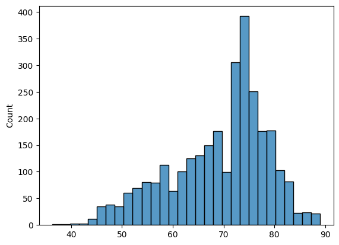

```python
life_expectancy = np.array(df_life['Life expectancy '].dropna())
sns.histplot(life_expectancy)
plt.show()
```

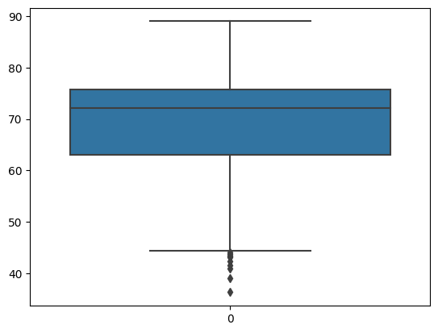

```python
sns.boxplot(data=life_expectancy)
plt.show()
```

```python
colors = ['#53BCD1','#B5E33A', '#f4d35e', '#e9724c', '#ffc857']
# Creamos nuevos dataframes para realizar gráficas
df_developed = df_life.loc[df_life['Status']=='Developed'].copy()
df_developing = df_life.loc[df_life['Status']=='Developing'].copy()
```

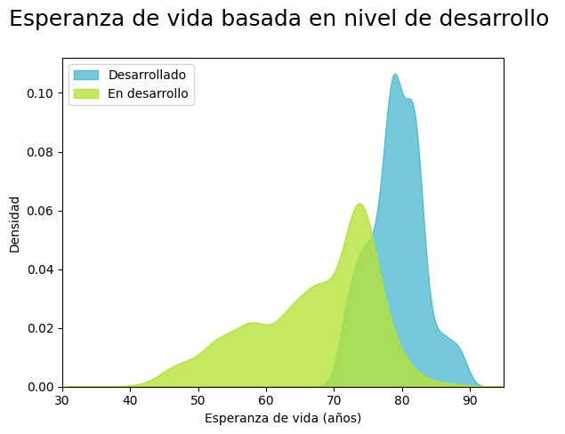

```python
# Graficar la densidad de la esperanza de vida por estado del país
sns.kdeplot(df_developed['Life expectancy '],  # Graficar la densidad de la esperanza de vida para los países desarrollados
            label='Desarrollado',  # Etiquetar la gráfica de densidad de los países desarrollados
            fill=True,  # Rellenar el área bajo la curva de densidad
            color = colors[0],   # Establecer el color de la gráfica de densidad de los países desarrollados
            alpha = 0.8)   # Establecer la transparencia de la gráfica de densidad de los países desarrollados

sns.kdeplot(df_developing['Life expectancy '],  # Graficar la densidad de la esperanza de vida para los países en desarrollo
            label='En desarrollo',  # Etiquetar la gráfica de densidad de los países en desarrollo
            fill=True,   # Rellenar el área bajo la curva de densidad
            color=colors[1],   # Establecer el color de la gráfica de densidad de los países en desarrollo
            alpha = 0.8)   # Establecer la transparencia de la gráfica de densidad de los países en desarrollo

plt.legend(loc='upper left') # Agregar una leyenda a la gráfica
plt.ylabel('Densidad')  # Etiquetar el eje y como "Densidad"
plt.xlim(30,95)  # Establecer los límites del eje x
plt.xlabel('Esperanza de vida (años)')  # Etiquetar el eje x como "Esperanza de vida (años)"
plt.title('Esperanza de vida basada en nivel de desarrollo \n', fontsize=18);  # Establecer el título de la gráfica
```

En esta gráfica de distribución kernel podemos notar que aunque la media de la esperanza de vida en las ciudades en desarrollo parece menor, también tienen una mayor dispersión, lo que nos lleva a formular la siguiente pregunta: ¿La diferencia en la esperanza de vida media será estadísticamente significativa?

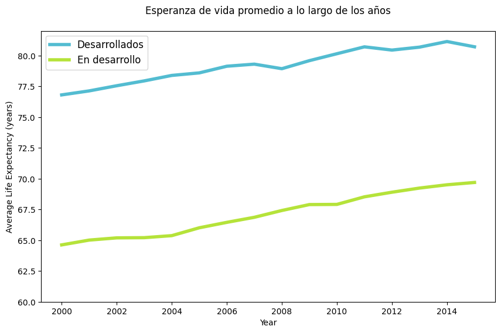

```python
# Graficamos la esperanza de vida promedio a lo largo de los años
fig, ax = plt.subplots(figsize=(10,6))

ax.plot(df_developed.groupby('Year')['Life expectancy '].mean(),
       label='Desarrollados',
       color=colors[0],
       linewidth=4)

ax.plot(df_developing.groupby('Year')['Life expectancy '].mean(),
       label='En desarrollo',
       color=colors[1],
       linewidth=4,)

plt.legend(loc='upper left', fontsize=12)
ax.set_xlabel('Year')
ax.set_ylabel('Average Life Expectancy (years)')

# Set y-axis limits
ax.set_ylim(60,82)

ax.set_title('Esperanza de vida promedio a lo largo de los años\n');
```

Vemos que el comportamiento de ambas variables a lo largo de los años resultó ser muy parecido, manteniendo una diferencia que parece casi constante.

## 6. Análisis estadístico inferencial

### 6.1 ¿La diferencia entre la esperanza media de vida de los paises desarrollados es mayor que en los paises en desarrollo? (Prueba de hipótesis)

Queremos verificar que la esperanza promedio en los países desarrollados y los países en vía de desarrollo es estadísticamente significativa. Esto puede abordarse a partir de la construcción de intervalos de confianza. Dado que la prueba "t" que se utiliza para esta comparación asume que las distribuciones son normales y tienen la misma dispersión, hemos decidido utilizar un enfoque no paramétrico, por esta razón utilizaremos la técnica de bootstrap para construir intervalos de confianza y comparar estos resultados para identificar diferencia significativa.

La técnica bootstrap es un método estadístico utilizado para aproximar la distribución de una estadística muestral, como la media, sin hacer suposiciones sobre la distribución subyacente de los datos. En lugar de obtener la distribución teórica exacta, la técnica bootstrap se basa en el muestreo con reemplazo de los datos disponibles para generar múltiples muestras "bootstrap" que son similares a la muestra original.

El proceso de bootstrap implica seguir los siguientes pasos:

Tomar una muestra de datos con reemplazo de la muestra original. Esto implica seleccionar aleatoriamente un punto de datos de la muestra original y devolverlo a la muestra antes de seleccionar el siguiente punto. Esto permite que un punto de datos se seleccione varias veces o no se seleccione en absoluto.

Calcular la estadística de interés (por ejemplo, la media) para cada una de las muestras bootstrap generadas en el paso anterior.

Repetir los pasos 1 y 2 un gran número de veces, generalmente miles de veces, para generar una distribución de la estadística muestral basada en las muestras bootstrap.

Una vez que se ha obtenido la distribución de la estadística muestral, se puede utilizar para construir intervalos de confianza. El intervalo de confianza proporciona un rango de valores dentro del cual es probable que se encuentre el verdadero valor del parámetro poblacional. Para construir un intervalo de confianza utilizando la técnica bootstrap, se seleccionan los percentiles específicos de la distribución de la estadística muestral. Por ejemplo, un intervalo de confianza del 95% se puede construir seleccionando el percentil 2.5 y el percentil 97.5 de la distribución bootstrap.

La técnica bootstrap es especialmente útil cuando no se cumplen los supuestos de normalidad o cuando la muestra es pequeña. Proporciona una forma robusta de aproximar la distribución de una estadística muestral y permite obtener intervalos de confianza más precisos sin depender de suposiciones teóricas.

```python
# Creamos nuevos dataframes para realizar gráficas
df_developed = df_life.loc[df_life['Status']=='Developed', 'Life expectancy '].dropna()
df_developing = df_life.loc[df_life['Status']=='Developing', 'Life expectancy '].dropna()

# Datos de las dos muestras
muestra1 = df_developed
muestra2 = df_developing
```

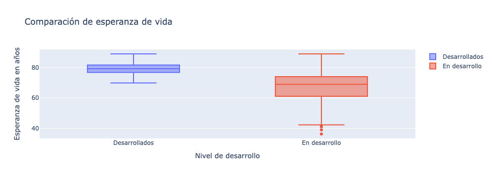

```python
fig = go.Figure()
# Graficamos
# Agregar los datos de los grupos al gráfico de caja
fig.add_trace(go.Box(y=muestra1, name='Desarrollados'))
fig.add_trace(go.Box(y=muestra2, name='En desarrollo'))

# Establecer el diseño del gráfico
fig.update_layout(
    title='Comparación de esperanza de vida',
    yaxis=dict(title='Esperanza de vida en años'),
    xaxis=dict(title='Nivel de desarrollo')
)

# Mostrar el gráfico
fig.show()
```

```python
# Generar múltiples muestras bootstrap
num_samples = 1000  # Número de muestras bootstrap a generar
```

```python
# Tamaños de muestra
tam_muestra = df_life['Status'].value_counts()
tam_muestra.head()
```

```
Status
Developing    2426
Developed      512
Name: count, dtype: int64
```

```python
# Definimos el dataframe donde guardamos los resultados
bootstrap_results = pd.DataFrame()

for dev in  {'Developed', 'Developing'}:
    bootstrap_result_cum = []
    for i in range(num_samples):
        # Generamos la muestra
        bootstrap_sample = resample(df_life.loc[df_life['Status']== dev], replace=True, n_samples= tam_muestra[dev])
        # Calculamos la media
        bootstrap_mean= bootstrap_sample['Life expectancy '].mean()
        # Guardamos resultados
        bootstrap_result_cum.append(bootstrap_mean)
    bootstrap_results[dev]=bootstrap_result_cum


print(bootstrap_results.head())
```

```
   Developing  Developed
0   66.993380  79.078711
1   67.287288  79.214453
2   67.098883  79.052930
3   66.936138  79.296094
4   67.117915  79.214258
```

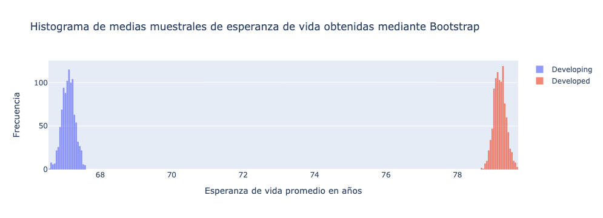

```python
#Gráfica comparación de las distribuciones muestrales simuladas mediante bootstrap
# Datos del histograma
x1 = bootstrap_results['Developing']
x2 = bootstrap_results['Developed']



# Crear la figura de histograma
fig = go.Figure()
fig.add_trace(go.Histogram(x=x1, name='Developing'))
fig.add_trace(go.Histogram(x=x2, name='Developed'))

# Configurar el diseño de la gráfica
fig.update_layout(
    title='Histograma de medias muestrales de esperanza de vida obtenidas mediante Bootstrap',
    xaxis_title='Esperanza de vida promedio en años',
    yaxis_title='Frecuencia',
    barmode='overlay',
    bargap=0.1
)
fig.update_traces(opacity=0.7)

# Mostrar la gráfica
fig.show()
```

A partir de la gráfica de arriba, vemos que de la técnica de bootstrap logramos aproximar las distribuciones de la media muestral de la esperanza de vida para distintos niveles de desarrollo. Es evidente, que al construir intervalos de confianza estos no se tocarán, por lo que podemos concluir que la diferencia en efecto es estadísticamente significativa.

```python
NC=0.95

confidence_interval1 = [np.percentile(x1, (100-NC)/2), np.percentile(x1, 50+ (NC/2))]
confidence_interval2 = [np.percentile(x2, (100-NC)/2), np.percentile(x2, 50+ (NC/2))]
print(f'Intervalo de confianza para la esperanza de vida promedio de los paises en desarrollo: {confidence_interval1}')
print(f'Intervalo de confianza para la esperanza de vida promedio de los paises  desarrollados: {confidence_interval2}')
```

```
Intervalo de confianza para la esperanza de vida promedio de los paises en desarrollo: [67.11295561169973, 67.11784675086743]
Intervalo de confianza para la esperanza de vida promedio de los paises  desarrollados: [79.17778598632813, 79.18237026367188]
```

### 6.2 ¿Qué variables tienen relación con la esperanza de vida? Análisis de regresión lineal múltiple

Realizaremos un análisis de regresión lineal para examinar la relación entre la esperanza de vida y otras variables.

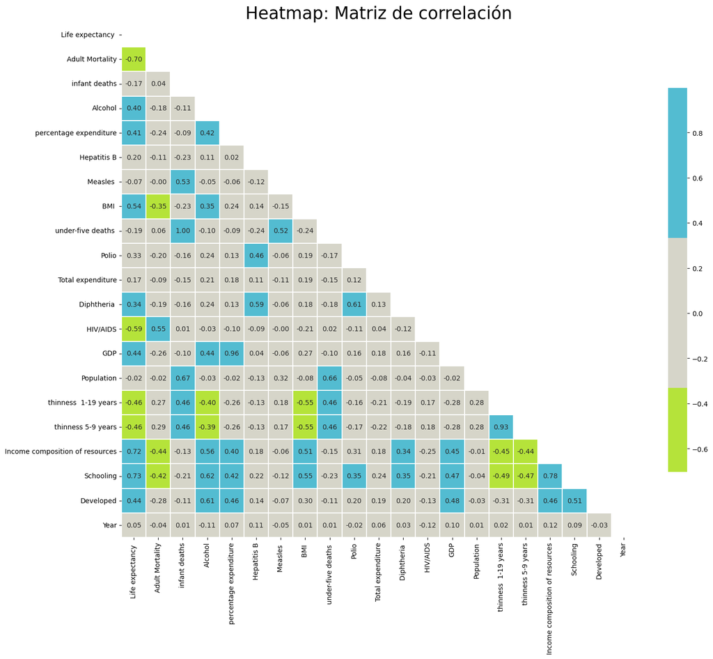

```python
#Graficamos la matriz de correlación
plt.figure(figsize=(17,17))

heatmap_colors = [colors[1], '#d6d5c9', colors[0]]

corr = df_estandarizado.corr()
mask = np.triu(np.ones_like(corr, dtype=bool))

sns.heatmap(df_estandarizado.corr(),
            mask=mask,
            center=0,
            annot=True,
            fmt='.2f',
            cmap=heatmap_colors,
            square=True,
            linewidths=.2,
            cbar_kws={"shrink": .6})

plt.title('Heatmap: Matriz de correlación', fontsize=25)
```

A partir de esta matriz de correlación seleccionamos las variables explicativas o predictoras a uncluir dentro del modelo de la siguiente manera:

**Seleccionadas para evitar colinealidad:**

1. Schooling
2. Adult mortality
3. BMI
4. Developed
5. Thinness 10-19 years
6. Polio

A continuación pasamos a obtener el primer modelo:

```python
# Seleccionamos las variables explicativas y target
X = df_estandarizado[['Schooling', 'Adult Mortality', ' BMI ', 'Developed', ' thinness  1-19 years', 'Polio']]  # Seleciona las columnas que serán tus variables independientes
y = df_estandarizado['Life expectancy ']  # Selecciona la columna que será tu variable dependiente

# Añadimos una constante
X = sm.add_constant(X)

# Creamos el modelo
model = sm.OLS(y, X)

# Ajustamos el modelo
results = model.fit()

print(results.summary())
```

```
                            OLS Regression Results
==============================================================================
Dep. Variable:       Life expectancy    R-squared:                       0.737
Model:                            OLS   Adj. R-squared:                  0.736
Method:                 Least Squares   F-statistic:                     765.4
Date:                Sun, 11 Jun 2023   Prob (F-statistic):               0.00
Time:                        20:48:26   Log-Likelihood:                -1108.7
No. Observations:                1649   AIC:                             2231.
Df Residuals:                    1642   BIC:                             2269.
Df Model:                           6
Covariance Type:            nonrobust
=========================================================================================
                            coef    std err          t      P>|t|      [0.025      0.975]
-----------------------------------------------------------------------------------------
const                    -0.0175      0.013     -1.351      0.177      -0.043       0.008
Schooling                 0.4541      0.020     22.336      0.000       0.414       0.494
Adult Mortality          -0.4174      0.013    -32.058      0.000      -0.443      -0.392
 BMI                      0.0943      0.016      6.060      0.000       0.064       0.125
Developed                 0.1267      0.039      3.271      0.001       0.051       0.203
 thinness  1-19 years    -0.0477      0.014     -3.408      0.001      -0.075      -0.020
Polio                     0.0536      0.013      4.103      0.000       0.028       0.079
==============================================================================
Omnibus:                      449.219   Durbin-Watson:                   0.839
Prob(Omnibus):                  0.000   Jarque-Bera (JB):             1783.576
Skew:                          -1.269   Prob(JB):                         0.00
Kurtosis:                       7.418   Cond. No.                         5.22
==============================================================================

Notes:
[1] Standard Errors assume that the covariance matrix of the errors is correctly specified.
```

Los resultados del modelo de regresión lineal múltiple indican lo siguiente:

- R-cuadrado (R-squared): El coeficiente de determinación R-squared es 0.737, lo que significa que aproximadamente el 73.7% de la variabilidad en la variable dependiente (esperanza de vida) puede ser explicada por las variables independientes incluidas en el modelo. Esto sugiere que el modelo tiene un buen ajuste y que las variables predictoras consideradas en el modelo son útiles para predecir la esperanza de vida.
- F-estadístico (F-statistic): El valor del F-estadístico es 765.4, y el valor p asociado es muy pequeño (prob (F-estadístico) = 0.00). Esto indica que el modelo en su conjunto es estadísticamente significativo, lo que significa que al menos una de las variables predictoras tiene un efecto significativo en la esperanza de vida.
- Coeficientes: Los coeficientes estimados para cada una de las variables predictoras muestran la relación entre cada variable y la esperanza de vida. Por ejemplo, el coeficiente para "Schooling" es 0.4541, lo que indica que un aumento de una unidad en el nivel educativo (Schooling) se asocia con un aumento de 0.4541 unidades en la esperanza de vida, manteniendo constantes las demás variables en el modelo.
- Estadísticos t y valores p: Para cada coeficiente, se proporciona un estadístico t y un valor p asociado. El estadístico t evalúa si el coeficiente estimado es significativamente diferente de cero. Los valores p indican la probabilidad de obtener un estadístico t tan extremo o más extremo si la hipótesis nula (el coeficiente es igual a cero) fuera verdadera. En este caso, todos los coeficientes tienen valores p muy pequeños (p < 0.05), lo que sugiere que todas las variables predictoras son estadísticamente significativas en relación con la esperanza de vida.
- En el caso de la constante (intercepto), el p-valor obtenido en la prueba individual t es alto (0.177), así que con un nivel de confianza del 95% no podemos rechazar la hipótesis nula de que este componente es significativo. Habría que plantear un nuevo modelo que no incluya este componente y evaluar si el modelo mejora.
- Errores estándar: Los errores estándar proporcionan una medida de la precisión de las estimaciones de los coeficientes. Un error estándar más pequeño indica una mayor precisión en la estimación del coeficiente.

Por lo tanto, los resultados del análisis de regresión lineal múltiple indican que las variables predictoras consideradas en el modelo (Schooling, Adult Mortality, BMI, Developed, thinness 1-19 years y Polio) tienen un impacto estadísticamente significativo en la esperanza de vida. Estos resultados proporcionan información valiosa para comprender y predecir los factores que influyen en la esperanza de vida en la población estudiada.

Sin embargo, es importante tener en cuenta que el modelo asume varias hipótesis, entre ellas una relación lineal entre las variables, y que existen otras variables que pueden influir en la esperanza de vida y que no se han incluido en el modelo.

En resumen, aunque el modelo de regresión lineal múltiple tiene un buen ajuste y las variables predictoras son significativas en relación con la esperanza de vida, se observa incumplimiento de algunas suposiciones clave del modelo, como la normalidad de los residuos. Esto sugiere que hay otros factores o variables no considerados en el modelo que pueden influir en la esperanza de vida y que podrían mejorar la precisión del modelo. Es importante tener precaución al interpretar y generalizar los resultados debido a estas limitaciones.

```python
# Seleccionamos las variables explicativas y target
X = df_estandarizado[['Schooling', 'Adult Mortality', ' BMI ', ' thinness  1-19 years', 'Polio']]  # Seleciona las columnas que serán tus variables independientes
y = df_estandarizado['Life expectancy ']  # Selecciona la columna que será tu variable dependiente


# Creamos el modelo
model = sm.OLS(y, X)

# Ajustamos el modelo
results = model.fit()

print(results.summary())
```

```
                                 OLS Regression Results
=======================================================================================
Dep. Variable:       Life expectancy    R-squared (uncentered):                   0.735
Model:                            OLS   Adj. R-squared (uncentered):              0.734
Method:                 Least Squares   F-statistic:                              911.6
Date:                Sun, 11 Jun 2023   Prob (F-statistic):                        0.00
Time:                        20:48:26   Log-Likelihood:                         -1114.0
No. Observations:                1649   AIC:                                      2238.
Df Residuals:                    1644   BIC:                                      2265.
Df Model:                           5
Covariance Type:            nonrobust
=========================================================================================
                            coef    std err          t      P>|t|      [0.025      0.975]
-----------------------------------------------------------------------------------------
Schooling                 0.4784      0.019     25.243      0.000       0.441       0.516
Adult Mortality          -0.4205      0.013    -32.341      0.000      -0.446      -0.395
 BMI                      0.0933      0.016      5.983      0.000       0.063       0.124
 thinness  1-19 years    -0.0509      0.014     -3.642      0.000      -0.078      -0.024
Polio                     0.0546      0.013      4.175      0.000       0.029       0.080
==============================================================================
Omnibus:                      443.213   Durbin-Watson:                   0.843
Prob(Omnibus):                  0.000   Jarque-Bera (JB):             1776.558
Skew:                          -1.248   Prob(JB):                         0.00
Kurtosis:                       7.430   Cond. No.                         2.70
==============================================================================

Notes:
[1] R² is computed without centering (uncentered) since the model does not contain a constant.
[2] Standard Errors assume that the covariance matrix of the errors is correctly specified.
```

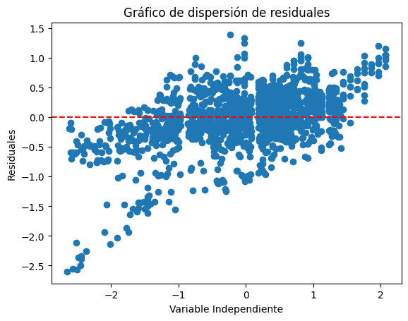

```python
y_pred = results.predict(X)


# Calcular los residuos
residuos = y - y_pred

# Graficar los residuales
plt.scatter(df_estandarizado['Life expectancy '], residuos)
plt.axhline(y=0, color='red', linestyle='--')
plt.xlabel('Variable Independiente')
plt.ylabel('Residuales')
plt.title('Gráfico de dispersión de residuales')
plt.show()
```

A partir de esta gráfica podemos concluir que el supuesto de homocedasticidad no se satisface. No parece que la varianza de los residuales se mantenga constante. Ahora queremos ver si el supuesto de normalidad se satisface. Para esto, comenzaremos graficando los residuales así como también construyendo un QQ-plot para comparar el comportamiento con el de una distribución normal.

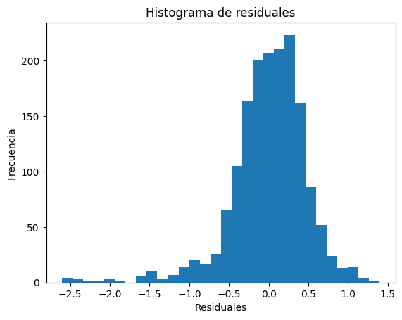

```python
# Graficar el histograma de residuales
plt.hist(residuos, bins=30)
plt.xlabel('Residuales')
plt.ylabel('Frecuencia')
plt.title('Histograma de residuales')
plt.show()
```

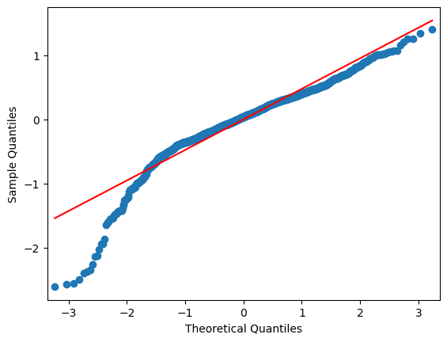

```python
from statsmodels.graphics.gofplots import qqplot

# Crear el QQ plot de los residuos
qqplot(residuos, line='s')

# Mostrar el gráfico
plt.show()
```

Al analizar las gráficas, podemos observar claramente que los residuos del modelo no siguen una distribución normal. El histograma muestra un sesgo hacia la izquierda, lo que indica una concentración de residuos con valores más bajos de lo esperado. Esto puede indicar la presencia de factores no considerados en el modelo que están influyendo en los resultados.

Además, al examinar el QQ-plot, podemos confirmar que los residuos no se ajustan a una línea recta. En lugar de seguir una distribución normal, los puntos del QQ-plot se desvían de la línea diagonal. Esto refuerza la evidencia de que los residuos no tienen un comportamiento normal y sugiere la presencia de otras fuentes de variabilidad que no están siendo capturadas por el modelo.

Es importante tener en cuenta que el incumplimiento del supuesto de normalidad no invalida completamente el modelo, especialmente si el tamaño de la muestra es lo suficientemente grande. Sin embargo, debemos ser cautelosos al interpretar los resultados y considerar la posibilidad de incluir más variables explicativas o utilizar técnicas alternativas que puedan abordar la falta de normalidad en los residuos, como modelos no lineales o transformaciones de las variables.

## 7. Resultados y conclusiones

Por otro lado, al realizar el análisis de regresión lineal múltiple, encontramos que el modelo utilizado explica aproximadamente el 73.7% de la variabilidad observada en la esperanza de vida. Esto indica que las variables incluidas en el modelo, como la escolaridad, la mortalidad adulta, el índice de masa corporal, el estado de desarrollo, el índice de delgadez en personas de 1 a 19 años y la cobertura de vacunación contra la polio, tienen una relación significativa con la esperanza de vida.

Sin embargo, al examinar los residuos del modelo, identificamos que no cumplen con el supuesto de normalidad. El histograma muestra un sesgo hacia la izquierda y el QQ-plot muestra una desviación de la línea diagonal, lo que indica la presencia de factores no considerados en el modelo. Estos resultados sugieren la necesidad de considerar otras variables o técnicas alternativas para mejorar la capacidad predictiva del modelo y capturar mejor la variabilidad observada en la esperanza de vida.

En resumen, nuestros análisis respaldan la relación entre el nivel de desarrollo y la esperanza de vida, y destacan la importancia de considerar otras variables y técnicas más sofisticadas en futuras investigaciones para mejorar la precisión de las predicciones y comprender más profundamente los determinantes de la esperanza de vida.